# Retail Price Optimization

**Table of contents**

- Retail Price Optimization
  - Introduction
  - Purpose
  - Questions
  - Data
    - Importing Data
  - Exploring The Data
  - Analyze  
    - What is the price elasticity for each product category?  
    - What is the total revenue per product sold?  
    - What are the total units sold per product?  
    - What is the total revenue per product category?  
    - What are the total units sold per category?  
    - What is the market demand of units sold per category?  
    - What is the market share of the company's units sold per category?  
    - What are the profit margins of each product?  
    - What is the profit margin of each category?  
    - What is the average product score per category compared to competitors?  
    - What is the average product score per product compared to competitors?
  - Conclusion  
    - Highlights  
    - Recommendations  
    - Next Steps

## Introduction

The following project is a fictional case study of a retail company that would like to optimize its pricing strategy based on the provided dataset.

The retail market is extremely competitive. Pricing is a key factor in attracting customers and ensuring a company's success. Several factors influence pricing decisions, including the cost of producing the goods, customer demand, competitor pricing, and the desired profit margin. Companies must carefully consider these factors to determine the most effective pricing strategy. This involves finding a balance between maximizing sales volume and maintaining profitability.

## Purpose

Leverage the data to develop a data-driven price optimization strategy that maximizes profits.

## Questions

- What is the total revenue/units sold per product?
- What is the total revenue/units sold per category?
- What is the market share of units sold per category?
- What is the profit margin of each product compared to other companies
- What is the average product score of each product/category compared to other companies?

## Data

The dataset provided, `retail_price.csv`, was downloaded from https://www.kaggle.com/datasets/suddharshan/retail-price-optimization/data, stored locally and is licensed as "CCO: Public Domain". The dataset contains 30 columns and 676 rows.

- **product_id (string) -** A unique identifier for each product in the dataset
- **product_category_name (string) -** Category for which the product belongs to
- **month_year (date) -** data in the format (dd-mm-yyyy) within the range between 01-01-2017 and 01-08-2018. Only months and years are important here.
- **qty (integer) -** Number of products sold in a given month
- **total_price (float) -** Montly revenue for a given product
- **freight_price (float) -** Freight price of the product
- **unit_price (float) -** Unit price of the product
- **product_name_length (integer) -** Number of characters in the product name
- **product_description_length (integer) -** Number of characters in the product description
- **product_photos_qty (integer) -** Number of photos available for the product
- **product_weight_g (integer) -** Unit weight in grams
- **product_score (float) -** User rating for the product
- **customers (integer) -** The number of customers who purchased a product in the given category that month (market demand)
- **weekday (integer) -** Number of weekdays per month
- **weekend (integer) -** Number of weekend days per month
- **holiday (integer) -** Number of holidays per month
- **month (integer) -** Month which was taken from the 'month_year' column
- **year (integer) -** Year which was taken from the 'month_year' column
- **s (float) -** The effect of seasonality - The total percentage share of sales during that month compared to annual sales
- **volume (integer) -** Unknown parameter - presumed to be total physical volume of the product
- **comp_1, comp_2, comp_3 (float) -** Unit price from 3 competitors
- **ps1, ps2, ps3 (float) -** Product score or review rating from 3 competitors
- **fp1, fp2, fp3 (float) -** Unit freight price from 3 competitors
- **lag_price (float) -** Unit price for the previous month

```python
#import libraries
import numpy as np
import pandas as pd
import seaborn as sns
import matplotlib.pyplot as plt
import datetime
import calendar
import statsmodels.api as sm

pd.set_option('display.max_columns', None)
import warnings
warnings.filterwarnings("ignore")
```

### Importing Data

```python
#importing dataset
df = pd.read_csv("retail_price.csv")
df.head()
```

|  | product_id | product_category_name | month_year | qty | total_price | freight_price | unit_price | product_name_lenght | product_description_lenght | product_photos_qty | product_weight_g | product_score | customers | weekday | weekend | holiday | month | year | s | volume | comp_1 | ps1 | fp1 | comp_2 | ps2 | fp2 | comp_3 | ps3 | fp3 | … |
| --- | --- | --- | --- | --- | --- | --- | --- | --- | --- | --- | --- | --- | --- | --- | --- | --- | --- | --- | --- | --- | --- | --- | --- | --- | --- | --- | --- | --- | --- | --- |
| 0 | bed1 | bed_bath_table | 01-05-2017 | 1 | 45.95 | 15.100000 | 45.95 | 39 | 161 | 2 | 350 | 4.0 | 57 | 23 | 8 | 1 | 5 | 2017 | 10.267394 | 3800 | 89.9 | 3.9 | 15.011897 | 215.000000 | 4.4 | 8.760000 | 45.95 | 4.0 | 15.100000 | … |
| 1 | bed1 | bed_bath_table | 01-06-2017 | 3 | 137.85 | 12.933333 | 45.95 | 39 | 161 | 2 | 350 | 4.0 | 61 | 22 | 8 | 1 | 6 | 2017 | 6.503115 | 3800 | 89.9 | 3.9 | 14.769216 | 209.000000 | 4.4 | 21.322000 | 45.95 | 4.0 | 12.933333 | … |
| 2 | bed1 | bed_bath_table | 01-07-2017 | 6 | 275.70 | 14.840000 | 45.95 | 39 | 161 | 2 | 350 | 4.0 | 123 | 21 | 10 | 1 | 7 | 2017 | 12.071651 | 3800 | 89.9 | 3.9 | 13.993833 | 205.000000 | 4.4 | 22.195932 | 45.95 | 4.0 | 14.840000 | … |
| 3 | bed1 | bed_bath_table | 01-08-2017 | 4 | 183.80 | 14.287500 | 45.95 | 39 | 161 | 2 | 350 | 4.0 | 90 | 23 | 8 | 1 | 8 | 2017 | 9.293873 | 3800 | 89.9 | 3.9 | 14.656757 | 199.509804 | 4.4 | 19.412885 | 45.95 | 4.0 | 14.287500 | … |
| 4 | bed1 | bed_bath_table | 01-09-2017 | 2 | 91.90 | 15.100000 | 45.95 | 39 | 161 | 2 | 350 | 4.0 | 54 | 21 | 9 | 1 | 9 | 2017 | 5.555556 | 3800 | 89.9 | 3.9 | 18.776522 | 163.398710 | 4.4 | 24.324687 | 45.95 | 4.0 | 15.100000 | … |

## Exploring The Data

```python
df.shape
```

```
(676, 30)
```

The dataset contains 676 rows and 30 columns.

```python
df.info()
```

```
<class 'pandas.core.frame.DataFrame'>
RangeIndex: 676 entries, 0 to 675
Data columns (total 30 columns):
 #   Column                      Non-Null Count  Dtype
---  ------                      --------------  -----
 0   product_id                  676 non-null    object
 1   product_category_name       676 non-null    object
 2   month_year                  676 non-null    object
 3   qty                         676 non-null    int64
 4   total_price                 676 non-null    float64
 5   freight_price               676 non-null    float64
 6   unit_price                  676 non-null    float64
 7   product_name_lenght         676 non-null    int64
 8   product_description_lenght  676 non-null    int64
 9   product_photos_qty          676 non-null    int64
```

[output cut: 22 more lines]

The "month_year" column should be converted to DateTime format and we'll correct some spelling mistakes.

```python
#convert month_year to date
df['month_year'] = pd.to_datetime(df['month_year'], format='%d-%m-%Y')

#rename columns
df = df.rename(columns={'product_name_lenght': 'product_name_length', 'product_description_lenght': 'product_description_length'})
df.info()
```

```
<class 'pandas.core.frame.DataFrame'>
RangeIndex: 676 entries, 0 to 675
Data columns (total 30 columns):
 #   Column                      Non-Null Count  Dtype
---  ------                      --------------  -----
 0   product_id                  676 non-null    object
 1   product_category_name       676 non-null    object
 2   month_year                  676 non-null    datetime64[ns]
 3   qty                         676 non-null    int64
 4   total_price                 676 non-null    float64
 5   freight_price               676 non-null    float64
 6   unit_price                  676 non-null    float64
 7   product_name_length         676 non-null    int64
 8   product_description_length  676 non-null    int64
 9   product_photos_qty          676 non-null    int64
```

[output cut: 22 more lines]

```python
#Dataset summary statistics
df.describe().T
```

|  | count | mean | min | 25% | 50% | 75% | max | std |
| --- | --- | --- | --- | --- | --- | --- | --- | --- |
| month_year | 676 | 2017-12-15 17:47:13.136094720 | 2017-01-01 00:00:00 | 2017-09-01 00:00:00 | 2018-01-01 00:00:00 | 2018-04-01 00:00:00 | 2018-08-01 00:00:00 | NaN |
| qty | 676.0 | 14.495562 | 1.0 | 4.0 | 10.0 | 18.0 | 122.0 | 15.443421 |
| total_price | 676.0 | 1422.708728 | 19.9 | 333.7 | 807.89 | 1887.3225 | 12095.0 | 1700.1231 |
| freight_price | 676.0 | 20.68227 | 0.0 | 14.761912 | 17.518472 | 22.713558 | 79.76 | 10.081817 |
| unit_price | 676.0 | 106.4968 | 19.9 | 53.9 | 89.9 | 129.99 | 364.0 | 76.182972 |
| product_name_length | 676.0 | 48.720414 | 29.0 | 40.0 | 51.0 | 57.0 | 60.0 | 9.420715 |
| product_description_length | 676.0 | 767.399408 | 100.0 | 339.0 | 501.0 | 903.0 | 3006.0 | 655.205015 |
| product_photos_qty | 676.0 | 1.994083 | 1.0 | 1.0 | 1.5 | 2.0 | 8.0 | 1.420473 |
| product_weight_g | 676.0 | 1847.498521 | 100.0 | 348.0 | 950.0 | 1850.0 | 9750.0 | 2274.808483 |
| product_score | 676.0 | 4.085503 | 3.3 | 3.9 | 4.1 | 4.2 | 4.5 | 0.232021 |
| customers | 676.0 | 81.028107 | 1.0 | 34.0 | 62.0 | 116.0 | 339.0 | 62.05556 |
| weekday | 676.0 | 21.773669 | 20.0 | 21.0 | 22.0 | 23.0 | 23.0 | 0.986104 |
| weekend | 676.0 | 8.658284 | 8.0 | 8.0 | 9.0 | 9.0 | 10.0 | 0.7056 |
| holiday | 676.0 | 1.494083 | 0.0 | 1.0 | 1.0 | 2.0 | 4.0 | 0.94043 |
| month | 676.0 | 6.192308 | 1.0 | 3.0 | 6.0 | 8.0 | 12.0 | 3.243455 |
| year | 676.0 | 2017.525148 | 2017.0 | 2017.0 | 2018.0 | 2018.0 | 2018.0 | 0.499737 |
| s | 676.0 | 14.64497 | 0.484262 | 7.510204 | 11.31676 | 17.745704 | 100.0 | 11.930276 |
| volume | 676.0 | 10664.627219 | 640.0 | 3510.0 | 8000.0 | 15750.0 | 32736.0 | 9172.80185 |
| comp_1 | 676.0 | 79.452054 | 19.9 | 49.91 | 69.9 | 104.256549 | 349.9 | 47.933358 |
| ps1 | 676.0 | 4.159467 | 3.7 | 4.1 | 4.2 | 4.2 | 4.5 | 0.121652 |
| fp1 | 676.0 | 18.59761 | 0.095439 | 13.826429 | 16.618984 | 19.7325 | 57.23 | 9.406537 |
| comp_2 | 676.0 | 92.930079 | 19.9 | 53.9 | 89.99 | 117.888889 | 349.9 | 49.481269 |
| ps2 | 676.0 | 4.123521 | 3.3 | 4.1 | 4.2 | 4.2 | 4.4 | 0.207189 |
| fp2 | 676.0 | 18.620644 | 4.41 | 14.485 | 16.811765 | 21.665238 | 57.23 | 6.424174 |
| comp_3 | 676.0 | 84.182642 | 19.9 | 53.785714 | 59.9 | 99.99 | 255.61 | 47.745789 |
| ps3 | 676.0 | 4.002071 | 3.5 | 3.9 | 4.0 | 4.1 | 4.4 | 0.233292 |
| fp3 | 676.0 | 17.965007 | 7.67 | 15.042727 | 16.51711 | 19.447778 | 57.23 | 5.533256 |
| lag_price | 676.0 | 107.399684 | 19.85 | 55.66875 | 89.9 | 129.99 | 364.0 | 76.974657 |

- The dataset contains data from January 2017 to August 2018.
- The freight_price column contains a minimum value of '0' so we would want to verify the accuracy of this with the company but for the purpose of this project, we will leave it as is.

```python
#create a "month_name" column
df["month_name"] = df.month.apply(lambda x: calendar.month_name[x])
df.month_name.head()
```

```
0          May
1         June
2         July
3       August
4    September
Name: month_name, dtype: object
```

```python
#product category value counts
product_counts = df.product_category_name.value_counts()
product_counts
```

```
product_category_name
garden_tools             160
health_beauty            130
watches_gifts            103
computers_accessories     69
bed_bath_table            61
cool_stuff                57
furniture_decor           48
perfumery                 26
consoles_games            22
Name: count, dtype: int64
```

The most popular product category is "garden_tools" followed by "health_beauty" and "watches_gifts".

```python
#product id value counts...top 10
df.product_id.value_counts().nlargest(10)
```

```
product_id
health5       20
health7       20
bed2          19
garden1       18
health9       18
garden3       18
computers4    18
health8       17
watches1      17
garden9       17
Name: count, dtype: int64
```

Note that most products do not contain sales data for every month in the dataset.

```python
#number of unique
df.nunique()
```

```
product_id                     52
product_category_name           9
month_year                     20
qty                            66
total_price                   573
freight_price                 653
unit_price                    280
product_name_length            24
product_description_length     46
product_photos_qty              7
product_weight_g               45
product_score                  11
customers                      94
weekday                         4
weekend                         3
holiday                         5
month                          12
year                            2
s                             450
volume                         40
comp_1                         88
ps1                             9
fp1                           179
comp_2                        123
ps2                            10
fp2                           242
comp_3                        105
ps3                             9
fp3                           229
lag_price                     307
month_name                     12
dtype: int64
```

```python
#number of duplicates
df.duplicated().sum()
```

```
0
```

```python
#number of missing values
df.isna().sum()
```

```
product_id                    0
product_category_name         0
month_year                    0
qty                           0
total_price                   0
freight_price                 0
unit_price                    0
product_name_length           0
product_description_length    0
product_photos_qty            0
product_weight_g              0
product_score                 0
customers                     0
weekday                       0
weekend                       0
holiday                       0
month                         0
year                          0
s                             0
volume                        0
comp_1                        0
ps1                           0
fp1                           0
comp_2                        0
ps2                           0
fp2                           0
comp_3                        0
ps3                           0
fp3                           0
lag_price                     0
month_name                    0
dtype: int64
```

## Analyze

```python
# total price per month
total_price_per_month = df.groupby('month_year')['total_price'].sum().reset_index()
total_price_per_month
```

|  | month_year | total_price |
| --- | --- | --- |
| 0 | 2017-01-01 | 2864.19 |
| 1 | 2017-02-01 | 3584.11 |
| 2 | 2017-03-01 | 10204.38 |
| 3 | 2017-04-01 | 11524.62 |
| 4 | 2017-05-01 | 21843.33 |
| 5 | 2017-06-01 | 23245.24 |
| 6 | 2017-07-01 | 41049.89 |
| 7 | 2017-08-01 | 49550.41 |
| 8 | 2017-09-01 | 44826.60 |
| 9 | 2017-10-01 | 48569.38 |
| 10 | 2017-11-01 | 87009.77 |
| 11 | 2017-12-01 | 65311.36 |
| 12 | 2018-01-01 | 77569.62 |
| 13 | 2018-02-01 | 88275.95 |
| 14 | 2018-03-01 | 85049.85 |
| 15 | 2018-04-01 | 75977.18 |
| 16 | 2018-05-01 | 91223.46 |
| 17 | 2018-06-01 | 50438.94 |
| 18 | 2018-07-01 | 46053.15 |
| 19 | 2018-08-01 | 37579.67 |

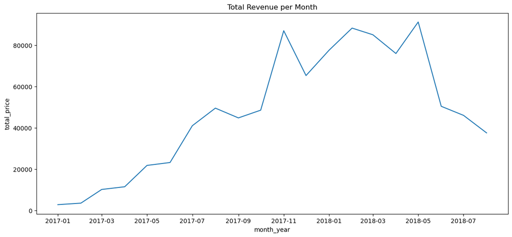

```python
# plot total revenue per month
plt.figure(figsize=(14,6))
sns.lineplot(data=total_price_per_month, x='month_year', y='total_price')
plt.title("Total Revenue per Month")
plt.show()
```

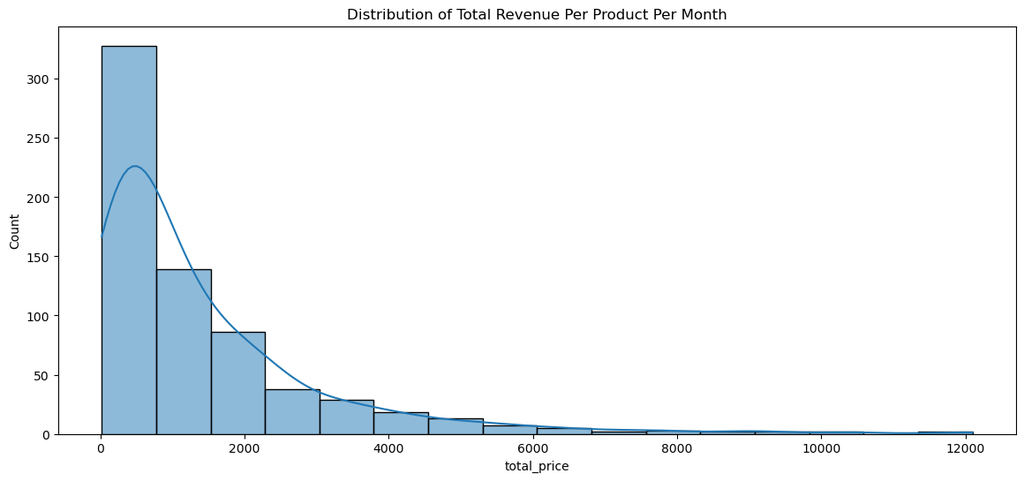

```python
# Distribution of total revenue per product per month
plt.figure(figsize=(14,6))
sns.histplot(df['total_price'], bins=16, kde=True)
plt.title("Distribution of Total Revenue Per Product Per Month")
plt.show()
```

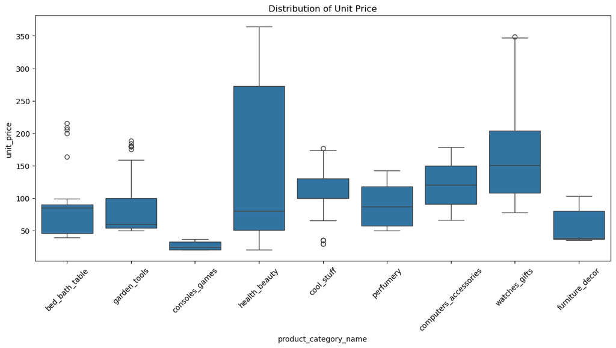

```python
# Distribution of unit price per product category
plt.figure(figsize=(14,6))
sns.boxplot(data=df, x="product_category_name", y="unit_price")
plt.title("Distribution of Unit Price")
plt.xticks(rotation=45)
plt.show()
```

Most product categories have a range of units prices within $50 or so. However, the `health_beauty` category has a larger price range of about $220.

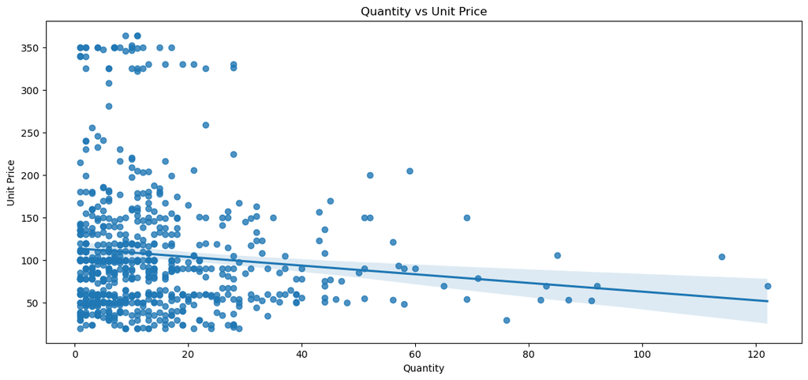

```python
# Quantity vs Unit Price
plt.figure(figsize=(14,6))
sns.regplot(data=df, x="qty", y="unit_price", )
plt.title("Quantity vs Unit Price")
plt.xlabel("Quantity")
plt.ylabel("Unit Price")
plt.show()
```

Generally, the higher the price, the lower the quanity sold which is to be expected but let's take a closer look at each category and product.

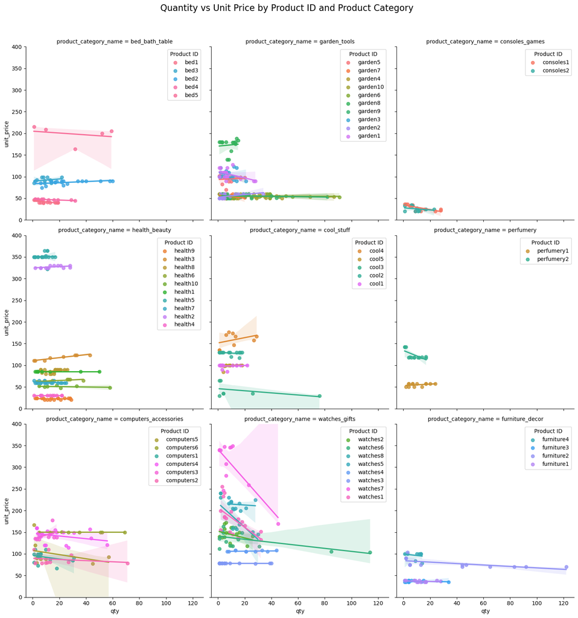

```python
# Quantity vs Unit Price using subplots for each category

# Create a FacetGrid
g = sns.lmplot(data=df, x="qty", y="unit_price", hue="product_id", col="product_category_name", col_wrap=3, legend=False)

# Add a legend to each plot
for ax in g.axes.flat:
    ax.legend(title="Product ID")
    ax.set_ylim(0, 400)

# Add a title to the figure
g.figure.suptitle("Quantity vs Unit Price by Product ID and Product Category", fontsize=16, y=1.05)

# Show the plot
plt.show()
```

The chart above demonstrates the relationship between quantity sold and unit price for each product. Note that the number of data points available for each product is relatively small.

##### What is the price elasticity for each product category?

```python
price_elasticity_values = []
p_value = []

# take the natural logarithm of the price and quantity variables
df['log_price'] = np.log(df['unit_price'])
df['log_quantity'] = np.log(df['qty'])

# run a linear regression of the log-transformed quantity on the log-transformed price for each category
for category in df['product_category_name'].unique():
    category_df = df[df['product_category_name'] == category]
    X = category_df['log_price']
    y = category_df['log_quantity']
    X = sm.add_constant(X)
    model = sm.OLS(y, X).fit()
    elasticity = model.params['log_price']
    price_elasticity_values.append(elasticity)
    p_value.append(model.f_pvalue)


# create a DataFrame for the results
price_elasticity_df = pd.DataFrame({'product_category_name': df['product_category_name'].unique(), 'price_elasticity': price_elasticity_values, 'p_value': p_value})

# print the results
price_elasticity_df.sort_values('price_elasticity', ascending=False)
```

|  | product_category_name | price_elasticity | p_value |
| --- | --- | --- | --- |
| 0 | bed_bath_table | 0.574007 | 0.045798 |
| 6 | computers_accessories | 0.398038 | 0.443906 |
| 8 | furniture_decor | 0.308026 | 0.456028 |
| 4 | cool_stuff | 0.136903 | 0.691564 |
| 3 | health_beauty | -0.144127 | 0.087363 |
| 7 | watches_gifts | -0.315897 | 0.217388 |
| 5 | perfumery | -0.579849 | 0.172494 |
| 1 | garden_tools | -0.798510 | 0.000169 |
| 2 | consoles_games | -2.275908 | 0.012395 |

How to interpret these values?

The price elasticity of a product is a measure of how responsive the quantity demanded is to changes in price. A positive price elasticity means that an increase in price leads to an increase in quantity demanded, while a negative price elasticity means that an increase in price leads to a decrease in quantity demanded. The magnitude of the number represents the strength of the relationship between price and quantity demanded.

Further, we are looking for p_values below 0.05. A p_value less than 0.05 means that the relationship between price and quantity demanded is statistically significant. A p_value greater than 0.05 means that the relationship between price and quantity demanded is not statistically significant and is more likely to be due to random chance.

The `bed_bath_table`, `garden_tools` and `console_game` categories appear to be statistically significant, however, we have multiple products in each category so let's take a closer look at the price elasticity for each product ID

```python
# Initialize empty lists to store results
price_elasticity_values = []
p_value = []
product_ids = []
avg_price_values = []
avg_qty_values = []

# take the natural logarithm of the price and quantity variables
df['log_price'] = np.log(df['unit_price'])
df['log_quantity'] = np.log(df['qty'])

# Loop through each product category
for product in df['product_id'].unique():
    product_df = df[df['product_id'] == product]
    X = product_df['log_price']
    y = product_df['log_quantity']
    X = sm.add_constant(X)
    model = sm.OLS(y, X).fit()
    elasticity = model.params['log_price']
    avg_price = product_df['unit_price'].mean()
    avg_qty = product_df['qty'].mean()
    p = model.f_pvalue

    # Only append results if p-value is below 0.05
    if p < 0.05:
        price_elasticity_values.append(elasticity)
        p_value.append(p)
        product_ids.append(product)
        avg_price_values.append(round(avg_price,2))
        avg_qty_values.append(round(avg_qty,1))

# Create a DataFrame for the results
price_elasticity_df = pd.DataFrame({
    'product_id': product_ids,
    'price_elasticity': price_elasticity_values,
    'p_value': p_value,
    'avg_price': avg_price_values,
    'avg_qty': avg_qty_values
})

# Sort the DataFrame by price elasticity in descending order
price_elasticity_df.sort_values('price_elasticity', ascending=False, inplace=True)

# Print the results
price_elasticity_df.reset_index(drop=True)
```

|  | product_id | price_elasticity | p_value | avg_price | avg_qty |
| --- | --- | --- | --- | --- | --- |
| 0 | health3 | 25.580232 | 0.002748 | 117.31 | 19.5 |
| 1 | health6 | 18.931870 | 0.043681 | 64.99 | 21.4 |
| 2 | cool4 | 8.250725 | 0.036349 | 158.79 | 12.0 |
| 3 | garden2 | 7.483709 | 0.007054 | 54.83 | 7.5 |
| 4 | watches1 | -2.734680 | 0.010957 | 180.63 | 11.4 |
| 5 | watches7 | -3.155533 | 0.039159 | 305.69 | 10.2 |
| 6 | consoles1 | -3.323191 | 0.001529 | 28.24 | 11.8 |
| 7 | watches8 | -4.110106 | 0.007972 | 184.50 | 11.7 |
| 8 | garden1 | -4.132643 | 0.049056 | 105.76 | 8.2 |
| 9 | bed1 | -9.896546 | 0.000265 | 42.21 | 8.9 |
| 10 | furniture2 | -10.208664 | 0.000750 | 77.51 | 40.5 |
| 11 | perfumery2 | -10.465497 | 0.000109 | 123.82 | 8.2 |
| 12 | bed4 | -29.834991 | 0.001636 | 46.73 | 13.1 |

When looking at `health3` for example, a price elasticity of 25.58 would suggest that an increase in price of 1% would lead to an increase in quantity demanded by 25.58%. Whereas with `bed4`, which has a price elasticity of -29.83, an increase in price of 1% would lead to a decrease in quantity demanded by 29.83%. The opposite is also true, where a decrease in price of 1% would lead to an increase in quantity demanded by 29.83%.

##### What is the total revenue per product sold?

```python
revenue_per_product = df.groupby('product_id')['total_price'].sum().reset_index()
revenue_per_product = revenue_per_product.sort_values('total_price', ascending=False)
revenue_per_product.nlargest(10, 'total_price')
```

|  | product_id | total_price |
| --- | --- | --- |
| 34 | health2 | 63885.00 |
| 37 | health5 | 54730.20 |
| 8 | computers4 | 46916.51 |
| 1 | bed2 | 42938.66 |
| 10 | computers6 | 41082.60 |
| 49 | watches6 | 37683.42 |
| 19 | furniture2 | 37608.90 |
| 44 | watches1 | 31786.82 |
| 50 | watches7 | 31623.81 |
| 48 | watches5 | 30467.50 |

From the list of top 10 products sold by revenue, `furniture2`, `watches1` and `watches7` are also in our price_elasticity_df dataframe. `furniture2` has the highest eleasticity of the 3 at "-10.2".

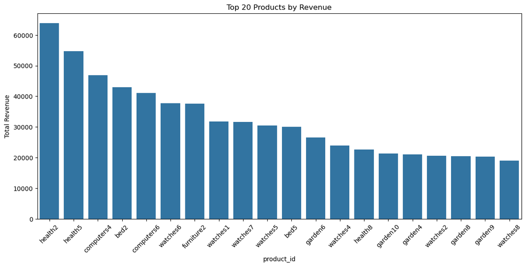

```python
#create bar chart of top 20 products by revenue
plt.figure(figsize=(14,6))
ax = sns.barplot(x='product_id', y='total_price', data=revenue_per_product.nlargest(20, 'total_price'))
plt.title("Top 20 Products by Revenue")
plt.xticks(rotation=45)
plt.ylabel("Total Revenue")
plt.show()
```

`health2` has the highest total revenue followed by `health5`, `computers4`, `bed2` and `computers6`.

##### What are the total units sold per product?

```python
units_per_product = df.groupby('product_id')['qty'].sum().reset_index()
units_per_product = units_per_product.sort_values('qty', ascending=False)
units_per_product.nlargest(10, 'qty')
```

|  | product_id | qty |
| --- | --- | --- |
| 19 | furniture2 | 527 |
| 1 | bed2 | 487 |
| 28 | garden6 | 484 |
| 23 | garden10 | 391 |
| 26 | garden4 | 388 |
| 31 | garden9 | 373 |
| 8 | computers4 | 341 |
| 49 | watches6 | 323 |
| 41 | health9 | 281 |
| 10 | computers6 | 274 |

From the list of top 10 products sold by quantity, `furniture2` is the only product in our price_elasticity_df dataframe. `furniture2` has a price elasticity of "-10.2".

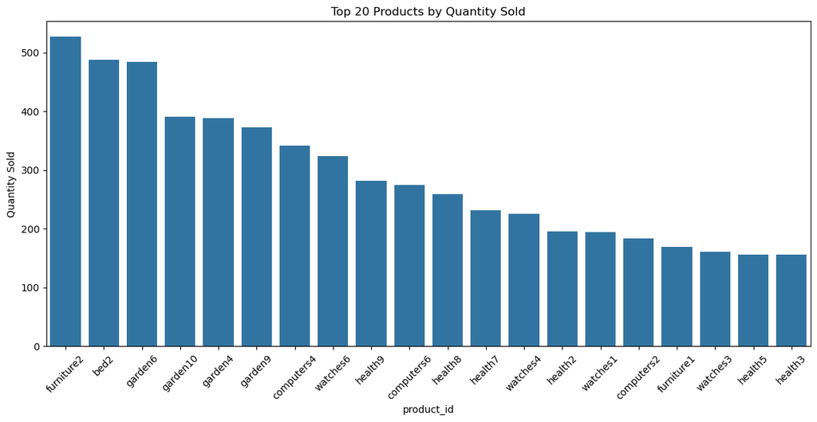

```python
#create bar chart of top 20 products by units sold
plt.figure(figsize=(14,6))
ax = sns.barplot(x='product_id', y='qty', data=units_per_product.nlargest(20, 'qty'))
plt.title("Top 20 Products by Quantity Sold")
plt.xticks(rotation=45)
plt.ylabel("Quantity Sold")
plt.show()
```

##### What is the total revenue per product category?

```python
revenue_per_category = df.groupby('product_category_name')['total_price'].sum().reset_index()
revenue_per_category = revenue_per_category.sort_values('total_price', ascending=False)
revenue_per_category
```

|  | product_category_name | total_price |
| --- | --- | --- |
| 6 | health_beauty | 212409.24 |
| 8 | watches_gifts | 207582.17 |
| 5 | garden_tools | 163582.54 |
| 1 | computers_accessories | 142097.95 |
| 0 | bed_bath_table | 95084.52 |
| 3 | cool_stuff | 57956.30 |
| 4 | furniture_decor | 56925.16 |
| 7 | perfumery | 20312.52 |
| 2 | consoles_games | 5800.70 |

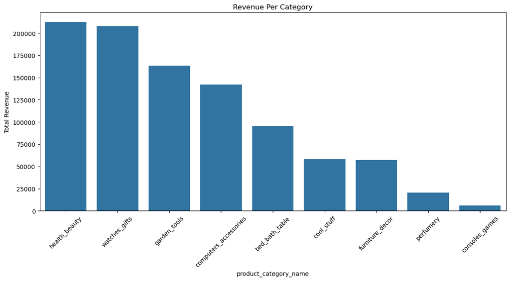

```python
#create bar chart of revenue per category
plt.figure(figsize=(14,6))
ax = sns.barplot(x='product_category_name', y='total_price', data=revenue_per_category)
plt.title("Revenue Per Category")
plt.xticks(rotation=45)
plt.ylabel("Total Revenue")
plt.show()
```

`health_beauty` and `watches_gifts` have the highest revenue followed by `garden_tools` and `computers_accessories`.

##### What are the total units sold per category?

```python
units_per_category = df.groupby('product_category_name')['qty'].sum().reset_index()
units_per_category = units_per_category.sort_values('qty', ascending=False)
units_per_category
```

|  | product_category_name | qty |
| --- | --- | --- |
| 5 | garden_tools | 2398 |
| 6 | health_beauty | 1842 |
| 8 | watches_gifts | 1431 |
| 1 | computers_accessories | 1167 |
| 0 | bed_bath_table | 1026 |
| 4 | furniture_decor | 894 |
| 3 | cool_stuff | 558 |
| 7 | perfumery | 244 |
| 2 | consoles_games | 239 |

##### What is the market demand of units sold per category?

```python
market_demand = df.groupby('product_category_name')['customers'].sum().sort_values(ascending=False).reset_index()
market_demand
```

|  | product_category_name | customers |
| --- | --- | --- |
| 0 | garden_tools | 17618 |
| 1 | health_beauty | 13765 |
| 2 | watches_gifts | 9743 |
| 3 | computers_accessories | 4807 |
| 4 | bed_bath_table | 3313 |
| 5 | furniture_decor | 2495 |
| 6 | cool_stuff | 2168 |
| 7 | consoles_games | 439 |
| 8 | perfumery | 427 |

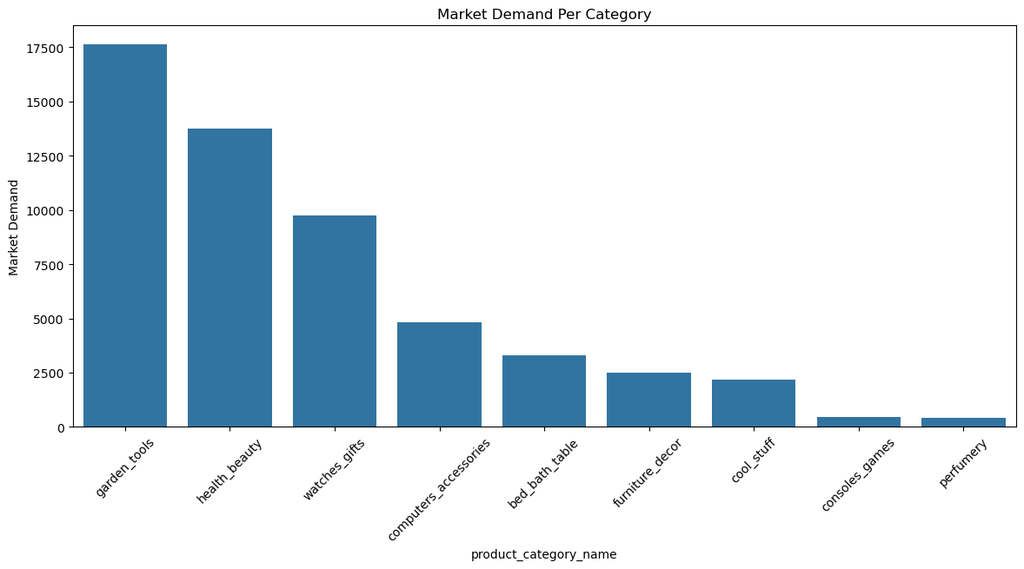

```python
#create bar chart of market demand per category
plt.figure(figsize=(14,6))
ax = sns.barplot(x='product_category_name', y='customers', data=market_demand)
plt.title("Market Demand Per Category")
plt.xticks(rotation=45)
plt.ylabel("Market Demand")
plt.show()
```

##### What is the market share of the company's units sold per category?

```python
market_demand_joined = pd.merge(units_per_category, market_demand, on="product_category_name")
market_demand_joined['market_share'] = (market_demand_joined.qty/market_demand_joined.customers*100).round(2)
market_demand_joined = market_demand_joined.sort_values('market_share', ascending=False)
market_demand_joined
```

|  | product_category_name | qty | customers | market_share |
| --- | --- | --- | --- | --- |
| 7 | perfumery | 244 | 427 | 57.14 |
| 8 | consoles_games | 239 | 439 | 54.44 |
| 5 | furniture_decor | 894 | 2495 | 35.83 |
| 4 | bed_bath_table | 1026 | 3313 | 30.97 |
| 6 | cool_stuff | 558 | 2168 | 25.74 |
| 3 | computers_accessories | 1167 | 4807 | 24.28 |
| 2 | watches_gifts | 1431 | 9743 | 14.69 |
| 0 | garden_tools | 2398 | 17618 | 13.61 |
| 1 | health_beauty | 1842 | 13765 | 13.38 |

```python
#join table with revenue per category
market_demand_joined = pd.merge(market_demand_joined, revenue_per_category, on='product_category_name')
market_demand_joined
```

|  | product_category_name | qty | customers | market_share | total_price |
| --- | --- | --- | --- | --- | --- |
| 0 | perfumery | 244 | 427 | 57.14 | 20312.52 |
| 1 | consoles_games | 239 | 439 | 54.44 | 5800.70 |
| 2 | furniture_decor | 894 | 2495 | 35.83 | 56925.16 |
| 3 | bed_bath_table | 1026 | 3313 | 30.97 | 95084.52 |
| 4 | cool_stuff | 558 | 2168 | 25.74 | 57956.30 |
| 5 | computers_accessories | 1167 | 4807 | 24.28 | 142097.95 |
| 6 | watches_gifts | 1431 | 9743 | 14.69 | 207582.17 |
| 7 | garden_tools | 2398 | 17618 | 13.61 | 163582.54 |
| 8 | health_beauty | 1842 | 13765 | 13.38 | 212409.24 |

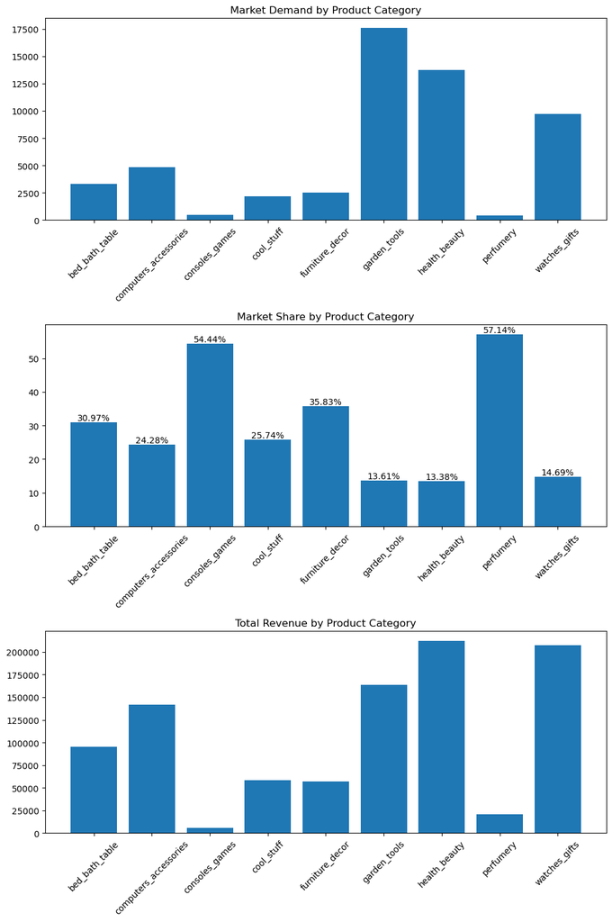

```python
#create a chart of customers vs market share vs total_price per product category
grouped_data = market_demand_joined.groupby('product_category_name')[['customers', 'market_share', 'total_price']].sum()

# Create a separate plot for each metric
fig, axs = plt.subplots(3, figsize=(10, 15))

axs[0].bar(grouped_data.index, grouped_data['customers'])
axs[0].set_title('Market Demand by Product Category')
axs[0].tick_params(axis='x', rotation=45)

axs[1].bar(grouped_data.index, grouped_data['market_share'])
axs[1].set_title('Market Share by Product Category')
axs[1].tick_params(axis='x', rotation=45)
#add labels to each bar
for i, v in enumerate(grouped_data['market_share']):
    axs[1].text(i, v, f"{v:.2f}%", ha='center', va='bottom')

axs[2].bar(grouped_data.index, grouped_data['total_price'])
axs[2].set_title('Total Revenue by Product Category')
axs[2].tick_params(axis='x', rotation=45)

plt.tight_layout()
plt.show()
```

From the charts above, we see that the highest market demand categories are `garden_tools`, `health_beauty` and `watches_gifts`. These 3 categories also represent the highest revenue categories for the company, however, they also represent the lowest market share categories between 13%-15%. Thus, there may be some opportunities to explore further in these categories.

The company has a dominant market share in the `console_games` and `perfumery` categories, however, those 2 categories also represent the lowest market demand.

##### What are the profit margins of each product?

```python
#calculate profit margin of each product
df['profit'] = df['unit_price'] - df['freight_price']
df['profit_margin'] = (df['profit']/df['unit_price']*100).round(2)
df.head()
```

|  | product_id | product_category_name | month_year | qty | total_price | freight_price | unit_price | product_name_length | product_description_length | product_photos_qty | product_weight_g | product_score | customers | weekday | weekend | holiday | month | year | s | volume | comp_1 | ps1 | fp1 | comp_2 | ps2 | fp2 | comp_3 | ps3 | fp3 | … |
| --- | --- | --- | --- | --- | --- | --- | --- | --- | --- | --- | --- | --- | --- | --- | --- | --- | --- | --- | --- | --- | --- | --- | --- | --- | --- | --- | --- | --- | --- | --- |
| 0 | bed1 | bed_bath_table | 2017-05-01 | 1 | 45.95 | 15.100000 | 45.95 | 39 | 161 | 2 | 350 | 4.0 | 57 | 23 | 8 | 1 | 5 | 2017 | 10.267394 | 3800 | 89.9 | 3.9 | 15.011897 | 215.000000 | 4.4 | 8.760000 | 45.95 | 4.0 | 15.100000 | … |
| 1 | bed1 | bed_bath_table | 2017-06-01 | 3 | 137.85 | 12.933333 | 45.95 | 39 | 161 | 2 | 350 | 4.0 | 61 | 22 | 8 | 1 | 6 | 2017 | 6.503115 | 3800 | 89.9 | 3.9 | 14.769216 | 209.000000 | 4.4 | 21.322000 | 45.95 | 4.0 | 12.933333 | … |
| 2 | bed1 | bed_bath_table | 2017-07-01 | 6 | 275.70 | 14.840000 | 45.95 | 39 | 161 | 2 | 350 | 4.0 | 123 | 21 | 10 | 1 | 7 | 2017 | 12.071651 | 3800 | 89.9 | 3.9 | 13.993833 | 205.000000 | 4.4 | 22.195932 | 45.95 | 4.0 | 14.840000 | … |
| 3 | bed1 | bed_bath_table | 2017-08-01 | 4 | 183.80 | 14.287500 | 45.95 | 39 | 161 | 2 | 350 | 4.0 | 90 | 23 | 8 | 1 | 8 | 2017 | 9.293873 | 3800 | 89.9 | 3.9 | 14.656757 | 199.509804 | 4.4 | 19.412885 | 45.95 | 4.0 | 14.287500 | … |
| 4 | bed1 | bed_bath_table | 2017-09-01 | 2 | 91.90 | 15.100000 | 45.95 | 39 | 161 | 2 | 350 | 4.0 | 54 | 21 | 9 | 1 | 9 | 2017 | 5.555556 | 3800 | 89.9 | 3.9 | 18.776522 | 163.398710 | 4.4 | 24.324687 | 45.95 | 4.0 | 15.100000 | … |

```python
#calculate profit margin of each product for each competitor (comp_1, comp_2, comp_3)
df['comp_1_profit'] = df['comp_1'] - df['fp1']
df['comp_2_profit'] = df['comp_2'] - df['fp2']
df['comp_3_profit'] = df['comp_3'] - df['fp3']
df['comp_1_profit_margin'] = (df['comp_1_profit']/df['comp_1']*100).round(2)
df['comp_2_profit_margin'] = (df['comp_2_profit']/df['comp_2']*100).round(2)
df['comp_3_profit_margin'] = (df['comp_3_profit']/df['comp_3']*100).round(2)
df.head()
```

|  | product_id | product_category_name | month_year | qty | total_price | freight_price | unit_price | product_name_length | product_description_length | product_photos_qty | product_weight_g | product_score | customers | weekday | weekend | holiday | month | year | s | volume | comp_1 | ps1 | fp1 | comp_2 | ps2 | fp2 | comp_3 | ps3 | fp3 | … |
| --- | --- | --- | --- | --- | --- | --- | --- | --- | --- | --- | --- | --- | --- | --- | --- | --- | --- | --- | --- | --- | --- | --- | --- | --- | --- | --- | --- | --- | --- | --- |
| 0 | bed1 | bed_bath_table | 2017-05-01 | 1 | 45.95 | 15.100000 | 45.95 | 39 | 161 | 2 | 350 | 4.0 | 57 | 23 | 8 | 1 | 5 | 2017 | 10.267394 | 3800 | 89.9 | 3.9 | 15.011897 | 215.000000 | 4.4 | 8.760000 | 45.95 | 4.0 | 15.100000 | … |
| 1 | bed1 | bed_bath_table | 2017-06-01 | 3 | 137.85 | 12.933333 | 45.95 | 39 | 161 | 2 | 350 | 4.0 | 61 | 22 | 8 | 1 | 6 | 2017 | 6.503115 | 3800 | 89.9 | 3.9 | 14.769216 | 209.000000 | 4.4 | 21.322000 | 45.95 | 4.0 | 12.933333 | … |
| 2 | bed1 | bed_bath_table | 2017-07-01 | 6 | 275.70 | 14.840000 | 45.95 | 39 | 161 | 2 | 350 | 4.0 | 123 | 21 | 10 | 1 | 7 | 2017 | 12.071651 | 3800 | 89.9 | 3.9 | 13.993833 | 205.000000 | 4.4 | 22.195932 | 45.95 | 4.0 | 14.840000 | … |
| 3 | bed1 | bed_bath_table | 2017-08-01 | 4 | 183.80 | 14.287500 | 45.95 | 39 | 161 | 2 | 350 | 4.0 | 90 | 23 | 8 | 1 | 8 | 2017 | 9.293873 | 3800 | 89.9 | 3.9 | 14.656757 | 199.509804 | 4.4 | 19.412885 | 45.95 | 4.0 | 14.287500 | … |
| 4 | bed1 | bed_bath_table | 2017-09-01 | 2 | 91.90 | 15.100000 | 45.95 | 39 | 161 | 2 | 350 | 4.0 | 54 | 21 | 9 | 1 | 9 | 2017 | 5.555556 | 3800 | 89.9 | 3.9 | 18.776522 | 163.398710 | 4.4 | 24.324687 | 45.95 | 4.0 | 15.100000 | … |

```python
#create profit margin table by product
profit_margin = df.groupby(['product_id','product_category_name'])[['profit_margin', 'comp_1_profit_margin', 'comp_2_profit_margin', 'comp_3_profit_margin']].mean().sort_values('profit_margin', ascending=False).reset_index()
profit_margin.nlargest(50, 'profit_margin') #view top 20 products by profit margin
```

|  | product_id | product_category_name | profit_margin | comp_1_profit_margin | comp_2_profit_margin | comp_3_profit_margin |
| --- | --- | --- | --- | --- | --- | --- |
| 0 | watches7 | watches_gifts | 94.575833 | 90.323333 | 86.258333 | 89.127500 |
| 1 | health2 | health_beauty | 94.078462 | 46.175385 | 82.131538 | 73.611538 |
| 2 | watches5 | watches_gifts | 92.497000 | 90.886000 | 87.119000 | 89.181000 |
| 3 | health5 | health_beauty | 92.276000 | 44.004000 | 84.319000 | 74.480000 |
| 4 | watches8 | watches_gifts | 90.823000 | 90.687000 | 84.421000 | 88.833000 |
| 5 | bed5 | bed_bath_table | 90.056000 | 82.822000 | 90.056000 | 68.548000 |
| 6 | watches6 | watches_gifts | 89.897143 | 89.897143 | 85.543571 | 89.221429 |
| 7 | watches1 | watches_gifts | 89.468235 | 90.024706 | 86.182353 | 89.468235 |
| 8 | perfumery2 | perfumery | 87.715385 | 77.291538 | 87.715385 | 87.715385 |
| 9 | watches2 | watches_gifts | 87.022000 | 89.934667 | 84.922667 | 89.207333 |
| 10 | cool4 | cool_stuff | 86.622222 | 82.546667 | 84.111111 | 75.362222 |
| 11 | computers5 | computers_accessories | 84.776250 | 68.695000 | 83.393750 | 81.081250 |
| 12 | cool2 | cool_stuff | 84.768462 | 83.324615 | 84.768462 | 77.136154 |
| 13 | computers1 | computers_accessories | 83.188667 | 70.503333 | 83.562667 | 82.606000 |
| 14 | bed3 | bed_bath_table | 83.022727 | 77.830000 | 83.022727 | 62.197273 |
| 15 | cool1 | cool_stuff | 82.776667 | 82.776667 | 84.028000 | 75.490667 |
| 16 | health8 | health_beauty | 82.714118 | 42.639412 | 82.714118 | 73.740000 |
| 17 | watches4 | watches_gifts | 82.491000 | 88.586000 | 82.491000 | 88.077000 |
| 18 | computers6 | computers_accessories | 82.266250 | 67.268750 | 82.266250 | 80.658750 |
| 19 | cool5 | cool_stuff | 81.423077 | 83.380000 | 84.512308 | 72.843077 |
| 20 | watches3 | watches_gifts | 80.916000 | 88.412667 | 82.093333 | 89.408667 |
| 21 | computers2 | computers_accessories | 80.818000 | 68.408000 | 82.104000 | 80.818000 |
| 22 | bed2 | bed_bath_table | 80.201579 | 80.201579 | 82.105263 | 67.394737 |
| 23 | computers3 | computers_accessories | 80.029000 | 74.145000 | 80.716000 | 82.642000 |
| 24 | health1 | health_beauty | 79.768889 | 43.015556 | 83.241111 | 70.448889 |
| 25 | furniture2 | furniture_decor | 78.707692 | 78.707692 | 62.237692 | 76.707692 |
| 26 | health10 | health_beauty | 76.502857 | 44.937143 | 81.362857 | 76.581429 |
| 27 | furniture4 | furniture_decor | 75.703000 | 78.303000 | 59.987000 | 75.703000 |
| 28 | perfumery1 | perfumery | 75.146154 | 75.146154 | 85.570000 | 75.146154 |
| 29 | garden8 | garden_tools | 74.565000 | 68.851429 | 63.191429 | 65.970714 |
| 30 | health7 | health_beauty | 74.480000 | 42.465000 | 82.108000 | 74.480000 |
| 31 | computers4 | computers_accessories | 70.801667 | 70.801667 | 77.467222 | 77.696111 |
| 32 | health3 | health_beauty | 70.368750 | 45.023750 | 81.635000 | 74.703750 |
| 33 | garden6 | garden_tools | 67.649375 | 67.649375 | 62.267500 | 65.269375 |
| 34 | bed4 | bed_bath_table | 67.619000 | 77.945000 | 67.619000 | 62.580000 |
| 35 | garden7 | garden_tools | 66.287500 | 67.702500 | 62.173750 | 65.978750 |
| 36 | health4 | health_beauty | 64.778182 | 45.450000 | 81.648182 | 73.726364 |
| 37 | garden4 | garden_tools | 64.767857 | 67.487857 | 61.946429 | 64.767857 |
| 38 | bed1 | bed_bath_table | 64.181875 | 79.390000 | 70.903125 | 64.181875 |
| 39 | garden9 | garden_tools | 63.517059 | 67.745882 | 62.680588 | 65.996471 |
| 40 | garden1 | garden_tools | 63.214444 | 67.863889 | 63.080000 | 65.658889 |
| 41 | garden3 | garden_tools | 63.016111 | 67.460556 | 62.632222 | 65.496111 |
| 42 | garden10 | garden_tools | 62.267500 | 67.649375 | 62.267500 | 64.736250 |
| 43 | furniture1 | furniture_decor | 60.431538 | 76.901538 | 60.431538 | 72.520769 |
| 44 | health6 | health_beauty | 59.857143 | 43.618571 | 81.600000 | 75.830000 |
| 45 | furniture3 | furniture_decor | 59.808333 | 78.526667 | 60.536667 | 73.404167 |
| 46 | garden5 | garden_tools | 53.789286 | 67.985714 | 65.685714 | 64.929286 |
| 47 | cool3 | cool_stuff | 52.177143 | 67.790000 | 66.351429 | 52.177143 |
| 48 | garden2 | garden_tools | 50.401765 | 67.720588 | 62.655294 | 65.849412 |
| 49 | consoles2 | consoles_games | 43.811000 | 41.013000 | 43.811000 | 43.811000 |

The top 5 product with the highest profit margin are `watches7`, `health2`, `watches5`, `health5` and `watches8`. Note that the actual cost of goods is not available in this dataset. For the purpose of this project, we are only using the freight price to calculate the profit margin.

##### What is the profit margin of each category?

```python
#create profit margin table by category
profit_margin_category = df.groupby(['product_category_name'])[['profit_margin', 'comp_1_profit_margin', 'comp_2_profit_margin', 'comp_3_profit_margin']].mean().reset_index()

#add average profit margin column for the average of the comp_1, comp_2, and comp_3 profit margins
profit_margin_category['avg_pm_comps'] = profit_margin_category[['comp_1_profit_margin', 'comp_2_profit_margin', 'comp_3_profit_margin']].mean(axis=1)

profit_margin_category.sort_values('profit_margin', ascending=False)
```

|  | product_category_name | profit_margin | comp_1_profit_margin | comp_2_profit_margin | comp_3_profit_margin | avg_pm_comps |
| --- | --- | --- | --- | --- | --- | --- |
| 8 | watches_gifts | 88.268058 | 89.802524 | 84.886990 | 89.123689 | 87.937735 |
| 7 | perfumery | 81.430769 | 76.218846 | 86.642692 | 81.430769 | 81.430769 |
| 3 | cool_stuff | 79.771579 | 81.162456 | 82.149649 | 72.378772 | 78.563626 |
| 1 | computers_accessories | 79.232899 | 70.220580 | 81.178696 | 80.668696 | 77.355990 |
| 0 | bed_bath_table | 75.253443 | 79.405902 | 77.609344 | 64.920000 | 73.978415 |
| 6 | health_beauty | 73.893769 | 43.197385 | 81.682615 | 74.104077 | 66.328026 |
| 4 | furniture_decor | 68.407083 | 78.088958 | 60.854375 | 74.538542 | 71.160625 |
| 5 | garden_tools | 62.823437 | 67.795875 | 62.827500 | 65.482938 | 65.368771 |
| 2 | consoles_games | 42.805000 | 41.533182 | 44.076818 | 42.805000 | 42.805000 |

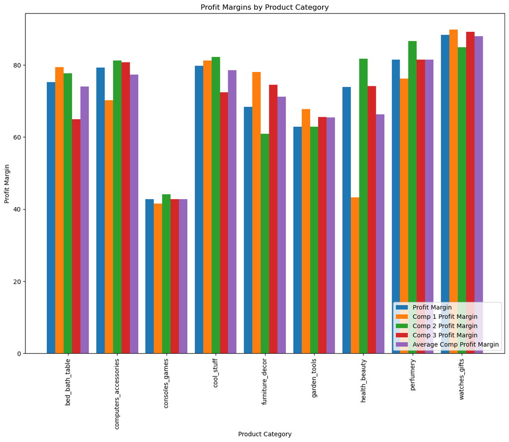

```python
#create bar chart of the profit margin by category
import matplotlib.pyplot as plt
import numpy as np
from matplotlib.lines import Line2D

# Create a figure and axis
fig, ax = plt.subplots(figsize=(14, 10))

# Define the data
product_categories = profit_margin_category['product_category_name'].unique()
profit_margins = profit_margin_category.groupby('product_category_name')['profit_margin'].mean().values
comp_1_profit_margins = profit_margin_category.groupby('product_category_name')['comp_1_profit_margin'].mean().values
comp_2_profit_margins = profit_margin_category.groupby('product_category_name')['comp_2_profit_margin'].mean().values
comp_3_profit_margins = profit_margin_category.groupby('product_category_name')['comp_3_profit_margin'].mean().values
avg_comp_profit_margins = profit_margin_category.groupby('product_category_name')['avg_pm_comps'].mean().values

# Set the x-axis values
x = np.arange(len(product_categories))

# Set the width of the bars
width = 0.17

# Create the bars
ax.bar(x - 2 * width, profit_margins, width, label='Profit Margin')
ax.bar(x - width, comp_1_profit_margins, width, label='Comp 1 Profit Margin')
ax.bar(x, comp_2_profit_margins, width, label='Comp 2 Profit Margin')
ax.bar(x + width, comp_3_profit_margins, width, label='Comp 3 Profit Margin')
ax.bar(x + 2 * width, avg_comp_profit_margins, width, label='Average Comp Profit Margin')

# Set the x-axis ticks
ax.set_xticks(x)

# Set the x-axis tick labels
ax.set_xticklabels(product_categories, rotation=90)

# Set the title and labels
ax.set_title('Profit Margins by Product Category')
ax.set_xlabel('Product Category')
ax.set_ylabel('Profit Margin')

# Add a legend
ax.legend(loc='lower right')

# Show the plot
plt.show()
```

```python
#merge the profit_margin_category table with the market_demand_joined table
pm_md_joined = pd.merge(profit_margin_category, market_demand_joined, on='product_category_name')
#rename totol_price column to total_revenue
pm_md_joined = pm_md_joined.rename(columns={'total_price': 'total_revenue'})
pm_md_joined
```

|  | product_category_name | profit_margin | comp_1_profit_margin | comp_2_profit_margin | comp_3_profit_margin | avg_pm_comps | qty | customers | market_share | total_revenue |
| --- | --- | --- | --- | --- | --- | --- | --- | --- | --- | --- |
| 0 | bed_bath_table | 75.253443 | 79.405902 | 77.609344 | 64.920000 | 73.978415 | 1026 | 3313 | 30.97 | 95084.52 |
| 1 | computers_accessories | 79.232899 | 70.220580 | 81.178696 | 80.668696 | 77.355990 | 1167 | 4807 | 24.28 | 142097.95 |
| 2 | consoles_games | 42.805000 | 41.533182 | 44.076818 | 42.805000 | 42.805000 | 239 | 439 | 54.44 | 5800.70 |
| 3 | cool_stuff | 79.771579 | 81.162456 | 82.149649 | 72.378772 | 78.563626 | 558 | 2168 | 25.74 | 57956.30 |
| 4 | furniture_decor | 68.407083 | 78.088958 | 60.854375 | 74.538542 | 71.160625 | 894 | 2495 | 35.83 | 56925.16 |
| 5 | garden_tools | 62.823437 | 67.795875 | 62.827500 | 65.482938 | 65.368771 | 2398 | 17618 | 13.61 | 163582.54 |
| 6 | health_beauty | 73.893769 | 43.197385 | 81.682615 | 74.104077 | 66.328026 | 1842 | 13765 | 13.38 | 212409.24 |
| 7 | perfumery | 81.430769 | 76.218846 | 86.642692 | 81.430769 | 81.430769 | 244 | 427 | 57.14 | 20312.52 |
| 8 | watches_gifts | 88.268058 | 89.802524 | 84.886990 | 89.123689 | 87.937735 | 1431 | 9743 | 14.69 | 207582.17 |

```python
#create a profit margin difference column to show the difference between the profit margin and the average comp profit margin
pm_md_joined['profit_margin_diff'] = pm_md_joined['profit_margin'] - pm_md_joined['avg_pm_comps']
pm_md_joined
```

|  | product_category_name | profit_margin | comp_1_profit_margin | comp_2_profit_margin | comp_3_profit_margin | avg_pm_comps | qty | customers | market_share | total_revenue | profit_margin_diff |
| --- | --- | --- | --- | --- | --- | --- | --- | --- | --- | --- | --- |
| 0 | bed_bath_table | 75.253443 | 79.405902 | 77.609344 | 64.920000 | 73.978415 | 1026 | 3313 | 30.97 | 95084.52 | 1.275027 |
| 1 | computers_accessories | 79.232899 | 70.220580 | 81.178696 | 80.668696 | 77.355990 | 1167 | 4807 | 24.28 | 142097.95 | 1.876908 |
| 2 | consoles_games | 42.805000 | 41.533182 | 44.076818 | 42.805000 | 42.805000 | 239 | 439 | 54.44 | 5800.70 | 0.000000 |
| 3 | cool_stuff | 79.771579 | 81.162456 | 82.149649 | 72.378772 | 78.563626 | 558 | 2168 | 25.74 | 57956.30 | 1.207953 |
| 4 | furniture_decor | 68.407083 | 78.088958 | 60.854375 | 74.538542 | 71.160625 | 894 | 2495 | 35.83 | 56925.16 | -2.753542 |
| 5 | garden_tools | 62.823437 | 67.795875 | 62.827500 | 65.482938 | 65.368771 | 2398 | 17618 | 13.61 | 163582.54 | -2.545333 |
| 6 | health_beauty | 73.893769 | 43.197385 | 81.682615 | 74.104077 | 66.328026 | 1842 | 13765 | 13.38 | 212409.24 | 7.565744 |
| 7 | perfumery | 81.430769 | 76.218846 | 86.642692 | 81.430769 | 81.430769 | 244 | 427 | 57.14 | 20312.52 | 0.000000 |
| 8 | watches_gifts | 88.268058 | 89.802524 | 84.886990 | 89.123689 | 87.937735 | 1431 | 9743 | 14.69 | 207582.17 | 0.330324 |

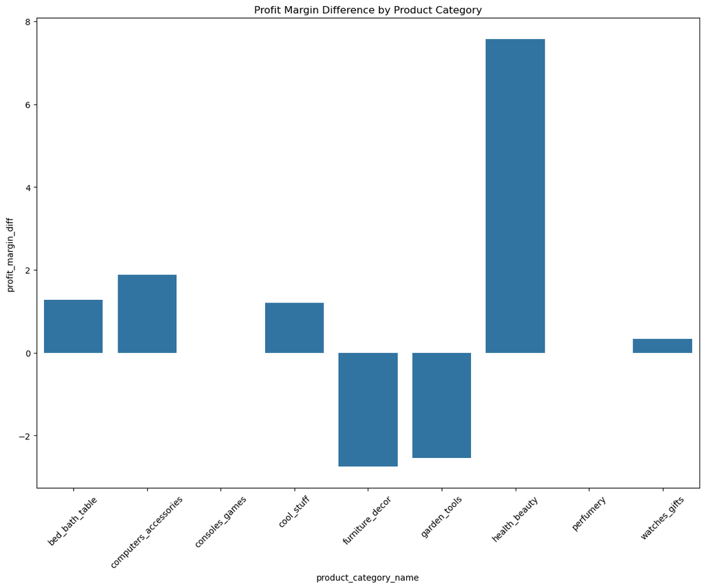

```python
# create a bar chart of the profit margin difference by category
fig, ax = plt.subplots(figsize=(14, 10))
sns.barplot(x='product_category_name', y='profit_margin_diff', data=pm_md_joined)
plt.title("Profit Margin Difference by Product Category")
plt.xticks(rotation=45)
plt.show()
```

The `health_beauty` category has significantly higher profit margin than the rest of the categories. `bed_bath_table`, `computers_accessories` and `cool_stuff` have moderately higer profit margins while `furniture_decor` and `garden_tools` have lower profit margins.

```python
#add an average_price column using the df table by product category
pm_md_joined['avg_price'] = df.groupby('product_category_name')['unit_price'].mean().reset_index(drop=True)
pm_md_joined
```

|  | product_category_name | profit_margin | comp_1_profit_margin | comp_2_profit_margin | comp_3_profit_margin | avg_pm_comps | qty | customers | market_share | total_revenue | profit_margin_diff | avg_price |
| --- | --- | --- | --- | --- | --- | --- | --- | --- | --- | --- | --- | --- |
| 0 | bed_bath_table | 75.253443 | 79.405902 | 77.609344 | 64.920000 | 73.978415 | 1026 | 3313 | 30.97 | 95084.52 | 1.275027 | 78.629278 |
| 1 | computers_accessories | 79.232899 | 70.220580 | 81.178696 | 80.668696 | 77.355990 | 1167 | 4807 | 24.28 | 142097.95 | 1.876908 | 119.482323 |
| 2 | consoles_games | 42.805000 | 41.533182 | 44.076818 | 42.805000 | 42.805000 | 239 | 439 | 54.44 | 5800.70 | 0.000000 | 27.033766 |
| 3 | cool_stuff | 79.771579 | 81.162456 | 82.149649 | 72.378772 | 78.563626 | 558 | 2168 | 25.74 | 57956.30 | 1.207953 | 107.857512 |
| 4 | furniture_decor | 68.407083 | 78.088958 | 60.854375 | 74.538542 | 71.160625 | 894 | 2495 | 35.83 | 56925.16 | -2.753542 | 60.154262 |
| 5 | garden_tools | 62.823437 | 67.795875 | 62.827500 | 65.482938 | 65.368771 | 2398 | 17618 | 13.61 | 163582.54 | -2.545333 | 80.094699 |
| 6 | health_beauty | 73.893769 | 43.197385 | 81.682615 | 74.104077 | 66.328026 | 1842 | 13765 | 13.38 | 212409.24 | 7.565744 | 132.309870 |
| 7 | perfumery | 81.430769 | 76.218846 | 86.642692 | 81.430769 | 81.430769 | 244 | 427 | 57.14 | 20312.52 | 0.000000 | 89.348813 |
| 8 | watches_gifts | 88.268058 | 89.802524 | 84.886990 | 89.123689 | 87.937735 | 1431 | 9743 | 14.69 | 207582.17 | 0.330324 | 164.880007 |

```python
#add an average price column of comp_1, comp_2, and comp_3 from the df table
avg_comp_price = df.groupby('product_category_name')[['comp_1', 'comp_2', 'comp_3']].mean().mean(axis=1)
pm_md_joined['avg_comp_price'] = pm_md_joined['product_category_name'].map(avg_comp_price)
pm_md_joined
```

|  | product_category_name | profit_margin | comp_1_profit_margin | comp_2_profit_margin | comp_3_profit_margin | avg_pm_comps | qty | customers | market_share | total_revenue | profit_margin_diff | avg_price | avg_comp_price |
| --- | --- | --- | --- | --- | --- | --- | --- | --- | --- | --- | --- | --- | --- |
| 0 | bed_bath_table | 75.253443 | 79.405902 | 77.609344 | 64.920000 | 73.978415 | 1026 | 3313 | 30.97 | 95084.52 | 1.275027 | 78.629278 | 76.860628 |
| 1 | computers_accessories | 79.232899 | 70.220580 | 81.178696 | 80.668696 | 77.355990 | 1167 | 4807 | 24.28 | 142097.95 | 1.876908 | 119.482323 | 128.258916 |
| 2 | consoles_games | 42.805000 | 41.533182 | 44.076818 | 42.805000 | 42.805000 | 239 | 439 | 54.44 | 5800.70 | 0.000000 | 27.033766 | 27.033766 |
| 3 | cool_stuff | 79.771579 | 81.162456 | 82.149649 | 72.378772 | 78.563626 | 558 | 2168 | 25.74 | 57956.30 | 1.207953 | 107.857512 | 101.278581 |
| 4 | furniture_decor | 68.407083 | 78.088958 | 60.854375 | 74.538542 | 71.160625 | 894 | 2495 | 35.83 | 56925.16 | -2.753542 | 60.154262 | 67.103577 |
| 5 | garden_tools | 62.823437 | 67.795875 | 62.827500 | 65.482938 | 65.368771 | 2398 | 17618 | 13.61 | 163582.54 | -2.545333 | 80.094699 | 58.712383 |
| 6 | health_beauty | 73.893769 | 43.197385 | 81.682615 | 74.104077 | 66.328026 | 1842 | 13765 | 13.38 | 212409.24 | 7.565744 | 132.309870 | 61.096288 |
| 7 | perfumery | 81.430769 | 76.218846 | 86.642692 | 81.430769 | 81.430769 | 244 | 427 | 57.14 | 20312.52 | 0.000000 | 89.348813 | 89.348813 |
| 8 | watches_gifts | 88.268058 | 89.802524 | 84.886990 | 89.123689 | 87.937735 | 1431 | 9743 | 14.69 | 207582.17 | 0.330324 | 164.880007 | 145.884183 |

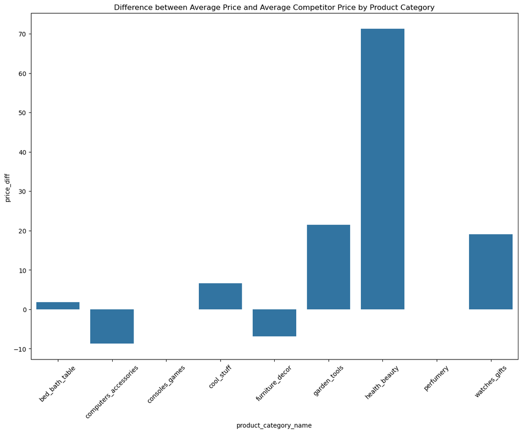

```python
#create a price_diff column to show the difference between the average price and the average comp price
pm_md_joined['price_diff'] = pm_md_joined['avg_price'] - pm_md_joined['avg_comp_price']

# Visualize the difference between avg price and avg comp price
fig, ax = plt.subplots(figsize=(14, 10))
sns.barplot(x='product_category_name', y='price_diff', data=pm_md_joined)
plt.title("Difference between Average Price and Average Competitor Price by Product Category")
plt.xticks(rotation=45)
plt.show()
```

The average price of products in the `health_beauty` category are significantly higher than the competition while `garden_tools` and `watches_gifts` are moderately higher and `computers_accessories` and `furniture_decor` are lower.

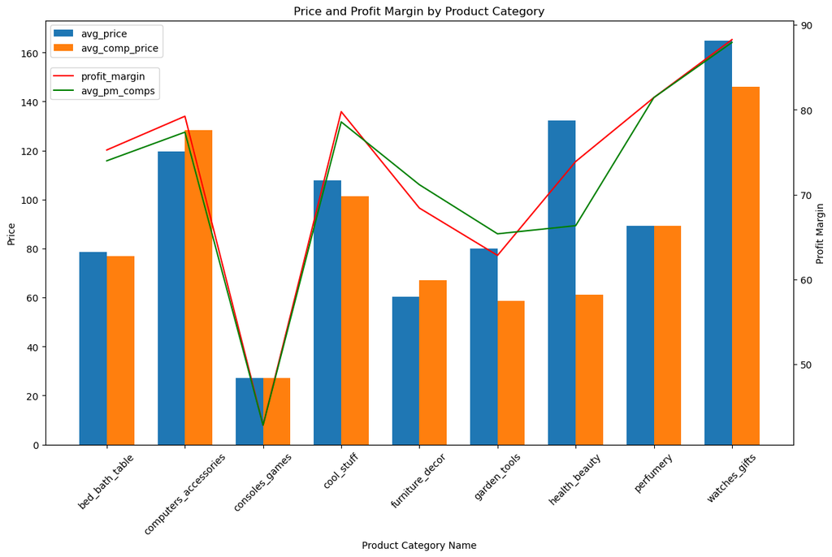

```python
# Create a figure and axis
fig, ax1 = plt.subplots(figsize=(14, 8))

# Set the x-coordinates of the bars
x = np.arange(len(pm_md_joined['product_category_name']))

# Set the width of the bars
width = 0.35

# Create a grouped bar chart for avg_price and avg_comp_price
ax1.bar(x - width/2, pm_md_joined['avg_price'], width, label='avg_price')
ax1.bar(x + width/2, pm_md_joined['avg_comp_price'], width, label='avg_comp_price')

# Create a line graph for profit_margin and avg_pm_comps
ax2 = ax1.twinx()
ax2.plot(x, pm_md_joined['profit_margin'], label='profit_margin', color='red')
ax2.plot(x, pm_md_joined['avg_pm_comps'], label='avg_pm_comps', color='green')

# Set labels and title
ax1.set_xlabel('Product Category Name')
ax1.set_ylabel('Price')
ax2.set_ylabel('Profit Margin')
ax1.set_title('Price and Profit Margin by Product Category')

# Set the x-axis tick labels
ax1.set_xticks(x)
ax1.set_xticklabels(pm_md_joined['product_category_name'], rotation=45)

# Add legend
ax1.legend(loc='upper left')
ax2.legend(bbox_to_anchor=(0, 0.9),loc='upper left')

# Show the plot
plt.show()
```

```python
# Average freight price per product ID
avg_freight_price = df.groupby('product_id')['freight_price'].mean().reset_index()
avg_freight_price
```

|  | product_id | freight_price |
| --- | --- | --- |
| 0 | bed1 | 15.025673 |
| 1 | bed2 | 17.063376 |
| 2 | bed3 | 15.665095 |
| 3 | bed4 | 15.157630 |
| 4 | bed5 | 19.203101 |
| 5 | computers1 | 15.037399 |
| 6 | computers2 | 16.634154 |
| 7 | computers3 | 28.077465 |
| 8 | computers4 | 40.611177 |
| 9 | computers5 | 14.471821 |
| 10 | computers6 | 26.588152 |
| 11 | consoles1 | 15.710161 |
| 12 | consoles2 | 13.728519 |
| 13 | cool1 | 16.828244 |
| 14 | cool2 | 19.508266 |
| 15 | cool3 | 20.748755 |
| 16 | cool4 | 21.384300 |
| 17 | cool5 | 18.296104 |
| 18 | furniture1 | 14.462504 |
| 19 | furniture2 | 16.734564 |
| 20 | furniture3 | 14.674080 |
| 21 | furniture4 | 23.169077 |
| 22 | garden1 | 38.498523 |
| 23 | garden10 | 20.445880 |
| 24 | garden2 | 26.672660 |
| 25 | garden3 | 38.502858 |
| 26 | garden4 | 18.867545 |
| 27 | garden5 | 43.845766 |
| 28 | garden6 | 17.585296 |
| 29 | garden7 | 18.266996 |
| 30 | garden8 | 42.728726 |
| 31 | garden9 | 19.818252 |
| 32 | health1 | 17.194581 |
| 33 | health10 | 11.878060 |
| 34 | health2 | 19.371875 |
| 35 | health3 | 34.689577 |
| 36 | health4 | 10.531775 |
| 37 | health5 | 27.139773 |
| 38 | health6 | 26.065083 |
| 39 | health7 | 15.396574 |
| 40 | health8 | 14.951347 |
| 41 | health9 | 13.806367 |
| 42 | perfumery1 | 13.599663 |
| 43 | perfumery2 | 15.072958 |
| 44 | watches1 | 18.437976 |
| 45 | watches2 | 18.369181 |
| 46 | watches3 | 14.882425 |
| 47 | watches4 | 18.583431 |
| 48 | watches5 | 16.183175 |
| 49 | watches6 | 13.531095 |
| 50 | watches7 | 15.724651 |
| 51 | watches8 | 16.074562 |

##### What is the average product score per category compared to competitors?

```python
# Average product score per category compared to competitors(ps_1, ps_2, ps_3)
avg_ps = df.groupby('product_category_name')[['product_score', 'ps1', 'ps2', 'ps3']].mean().reset_index()
avg_ps['avg_comp_ps'] = avg_ps[['ps1', 'ps2', 'ps3']].mean(axis=1)
avg_ps['ps_diff'] = avg_ps['product_score'] - avg_ps['avg_comp_ps']
avg_ps.sort_values('ps_diff', ascending=False)
```

|  | product_category_name | product_score | ps1 | ps2 | ps3 | avg_comp_ps | ps_diff |
| --- | --- | --- | --- | --- | --- | --- | --- |
| 6 | health_beauty | 4.145385 | 4.287692 | 4.103077 | 3.900000 | 4.096923 | 0.048462 |
| 5 | garden_tools | 4.161875 | 4.105000 | 4.197500 | 4.110625 | 4.137708 | 0.024167 |
| 2 | consoles_games | 4.063636 | 4.186364 | 3.940909 | 4.063636 | 4.063636 | 0.000000 |
| 7 | perfumery | 4.350000 | 4.307692 | 4.392308 | 4.350000 | 4.350000 | 0.000000 |
| 1 | computers_accessories | 3.985507 | 4.197101 | 4.192754 | 3.685507 | 4.025121 | -0.039614 |
| 8 | watches_gifts | 3.983495 | 4.173786 | 4.129126 | 3.800000 | 4.034304 | -0.050809 |
| 0 | bed_bath_table | 3.908197 | 3.900000 | 3.981967 | 3.995082 | 3.959016 | -0.050820 |
| 3 | cool_stuff | 4.207018 | 4.210526 | 4.303509 | 4.264912 | 4.259649 | -0.052632 |
| 4 | furniture_decor | 3.979167 | 4.085417 | 3.725000 | 4.285417 | 4.031944 | -0.052778 |

When comparing the average product score per category compared to competitors, there does not appear to be a significant difference between the average product score and the average competitor product score.

##### What is the average product score per product compared to competitors?

```python
# Average product score per product compared to competitors(ps_1, ps_2, ps_3)
avg_ps_per_product = df.groupby('product_id')[['product_score', 'ps1', 'ps2', 'ps3']].mean().reset_index()
avg_ps_per_product['avg_comp_ps'] = avg_ps_per_product[['ps1', 'ps2', 'ps3']].mean(axis=1)
# only show rows where product_score is +/- 0.2 of avg_comp_ps
avg_ps_per_product_filtered = avg_ps_per_product[abs(avg_ps_per_product['product_score'] - avg_ps_per_product['avg_comp_ps']) >= 0.2]
avg_ps_per_product_filtered['ps_diff'] = avg_ps_per_product_filtered['product_score'] - avg_ps_per_product_filtered['avg_comp_ps']
avg_ps_per_product_filtered.sort_values('ps_diff', ascending=False)
```

|  | product_id | product_score | ps1 | ps2 | ps3 | avg_comp_ps | ps_diff |
| --- | --- | --- | --- | --- | --- | --- | --- |
| 36 | health4 | 4.5 | 4.318182 | 4.100000 | 3.900000 | 4.106061 | 0.393939 |
| 21 | furniture4 | 4.4 | 4.100000 | 3.770000 | 4.400000 | 4.090000 | 0.310000 |
| 4 | bed5 | 4.4 | 3.900000 | 4.400000 | 4.000000 | 4.100000 | 0.300000 |
| 10 | computers6 | 4.3 | 4.200000 | 4.300000 | 3.500000 | 4.000000 | 0.300000 |
| 20 | furniture3 | 3.8 | 4.075000 | 3.708333 | 4.250000 | 4.011111 | -0.211111 |
| 18 | furniture1 | 3.7 | 4.069231 | 3.700000 | 4.184615 | 3.984615 | -0.284615 |
| 32 | health1 | 3.8 | 4.300000 | 4.100000 | 3.900000 | 4.100000 | -0.300000 |
| 50 | watches7 | 3.7 | 4.158333 | 4.075000 | 3.800000 | 4.011111 | -0.311111 |
| 16 | cool4 | 3.8 | 4.200000 | 4.300000 | 4.000000 | 4.166667 | -0.366667 |
| 2 | bed3 | 3.3 | 3.900000 | 3.300000 | 4.000000 | 3.733333 | -0.433333 |
| 9 | computers5 | 3.5 | 4.200000 | 4.100000 | 3.500000 | 3.933333 | -0.433333 |
| 6 | computers2 | 3.5 | 4.200000 | 4.140000 | 3.500000 | 3.946667 | -0.446667 |

The products listed above have a product score that is 0.2 or more away from the average competitor product score. The difference or similarity between product scores may play a factor in determining the price of the product.

## Conclusion

##### Highlights

The categories with most **market demand** are `garden_tools`, `health_beauty` and `watches_gifts`. These categories also represent the highest revenue categories for the company, however, they also represent the lowest market share categories between 13%-15%. Thus, there may be some opportunities to explore further in these categories.

The company has a dominant **market share** in the `console_games` and `perfumery` categories, however, those 2 categories also represent the lowest market demand.

The `health_beauty` category also has much higher **profit margins** than the rest. `bed_bath_table`, `computers_accessories` and `cool_stuff` have moderately higer profit margins while `furniture_decor` and `garden_tools` have lower profit margins.

The **average price** of products in the `health_beauty` category are significantly higher than the competition while `garden_tools` and `watches_gifts` are moderately higher and `computers_accessories` and `furniture_decor` are lower.

There are not enough data points to determine price elasticity for each product with a high degree of confidence but but we did get statistically significant results for the following:

```python
price_elasticity_df.reset_index(drop=True)
```

|  | product_id | price_elasticity | p_value | avg_price | avg_qty |
| --- | --- | --- | --- | --- | --- |
| 0 | health3 | 25.580232 | 0.002748 | 117.31 | 19.5 |
| 1 | health6 | 18.931870 | 0.043681 | 64.99 | 21.4 |
| 2 | cool4 | 8.250725 | 0.036349 | 158.79 | 12.0 |
| 3 | garden2 | 7.483709 | 0.007054 | 54.83 | 7.5 |
| 4 | watches1 | -2.734680 | 0.010957 | 180.63 | 11.4 |
| 5 | watches7 | -3.155533 | 0.039159 | 305.69 | 10.2 |
| 6 | consoles1 | -3.323191 | 0.001529 | 28.24 | 11.8 |
| 7 | watches8 | -4.110106 | 0.007972 | 184.50 | 11.7 |
| 8 | garden1 | -4.132643 | 0.049056 | 105.76 | 8.2 |
| 9 | bed1 | -9.896546 | 0.000265 | 42.21 | 8.9 |
| 10 | furniture2 | -10.208664 | 0.000750 | 77.51 | 40.5 |
| 11 | perfumery2 | -10.465497 | 0.000109 | 123.82 | 8.2 |
| 12 | bed4 | -29.834991 | 0.001636 | 46.73 | 13.1 |

##### Recommendations

1. `health3` and `health6` have a high price elasticity of 25.58 and 18.93 respectively. These products have sold higher quantities at higher prices, the category itself has a high market demand but the company has relatively low market share. I recommend experimenting with slightly higher prices for these products and monitor the results. If increasing prices results in higher sales or at least on par with current sales, I would recommend testing out higher prices for other products in the same category that did not have statistically significant price elasticities but might be perceived as a "premium" product. From a visual look at the "Quantity vs Unit Price by Product ID and Product Category" chart, `health2` and `health8` could be good candidates to experiment with.
2. `garden2` has a price elasticity of 7.48 and is part of a category that has a high market demand but low market share. I would recommend experimenting with slightly higher prices for this product and monitoring the results.
3. `watches1`, `watches7` and `garden1` have moderately low negative price elasticities. These products have a high market demand but low market share. `watches7` has a product score that is 0.3 lower than the competitor average. The average price of products in the watches and garden tools categories are also higher than the competition. I would recommend experimenting with slightly lower prices for these products and monitor the results to see if the increased demand results in higher total profit.

If we take a closer look at `garden1` for example, the average product price for the company is $105.76 with a average profit margin of 63.21%. The total average profit per sale would be $66.85. The average monthly sales have been 8.2 units translating to $548.18 in monthly profit. <br><br> If we were to decrease the price by 10% ($95.18), the demand should increase by 41.3% (11.6 units). The total profit per sale would be $56.68 (95.18 - 38.50). If we were to assume monthly sales to increase to 11.6 units, that would amount to $657.49 in monthly profit which is higher than the current monthly profit of $548.18.  
4. `furniture2` is the company's top selling product by units sold. Although this category doesn't have the same market demand as the other top selling categories, there is likely some potential to increase the market share. I would recommend experimenting with slightly lower prices for this product and monitoring the results.

##### Next Steps

1. If the above recommendations prove to be fruitful, we can experiment with the other products on the price_elasticity_df. Furthermore, as more data is collected, we can update the price_elasticity_df to see if we get more statistically significant results.
2. The actual cost of goods was not provided in this dataset. I would recommend including those costs in the future to determine the true profit margin of each product.
3. There are other variables from the dataset that were not investigated such as lag_price, seasonality and number of photos available on the listing. Lag price could be investigated to see if the the previous month's price has an effect on the current month's price. Seasonality could be investigated to optimize prices based on the season. Number of photos available on the listing could be investigated to see if including more photos has a relationship with increase sales.